# model_compare

April Wright

2023-09-01

Read in data.

```r
library(tidyverse)
library(reactable)
bfs <- read_csv("data/master_table_name_synonymized.csv")
```

```
## ──────────────────────────────────────────────────────── Delimiter: "," chr
## (2): Dataset, ...8 dbl (6): Infinity, 1, 0.2, 2, 0.05, 10
```

```r
avg <- read_csv("data/Model_averaging_results.csv")
```

Now, find the best fit model from Bayes Factors and add this as a column. Add a column with the max score in:

```r
labeled <- bfs %>%
  mutate(...8 = NULL) %>%
  rowwise() %>%
  group_by(`Dataset`) %>%
  mutate(maxval = max(c_across(everything())),
         max = names(cur_data())[which.max(c_across(everything()))])
```

Getting the second max is a trick.

```r
second_highest = bfs %>%
  mutate(...8 = NULL) %>%
  mutate(row = row_number()) %>%
  pivot_longer(c(-`Dataset`, -row)) %>%
  group_by(row) %>%
  arrange(desc(value)) %>%
  filter(row_number() == 2) %>%
  ungroup()

total_table <- inner_join(labeled, second_highest)
```

Now, we calculate our marginal liklelihood difference:

```r
calced <- total_table %>%
  mutate(diff = maxval - value)

calced <- calced %>%
  mutate(Jeff = case_when(diff < 3.2 ~ 'Barely',
  3.2 < diff  ~ 'Substantial',
  diff > 10 ~ 'Strong'))
```

Quick and dirty look at the results:

```r
reactable(calced, columns = list(
  Jeff = colDef(
    style = function(value, index) {
      if (calced$Jeff[index] == "Barely") {
        color <- "lightblue"
      } else if (calced$Jeff[index] == "Substantial") {
        color <- "lightgreen"
      } else if (calced$Jeff[index] == "Strong") {
        color <- "darkgreen"
      }
      list(color = color)
    }
  )
))
```

| Dataset | Infinity | 1 | 0.2 | 2 | 0.05 | 10 | maxval | max | row | name | value | diff | Jeff |
| --- | --- | --- | --- | --- | --- | --- | --- | --- | --- | --- | --- | --- | --- |
| Abella_etal_2012a | -614.76 | -612.600163 | -620.037927 | -611.51 | -637.16673 | -603.535274 | -603.535274 | 10 | 1 | 2 | -611.51 | 7.97472600000003 | Substantial |
| Adnet_et_Cappetta_2001a | -429.23 | -433.629579 | -462.389564 | -430.23 | -506.598402 | -430.538902 | -429.23 | Infinity | 2 | 2 | -430.23 | 1 | Barely |
| Aguilera_etal_2006a | -2600.32 | -2557.356469 | -2601.24763 | -2538.34 | -2705.029988 | -2536.233641 | -2536.233641 | 10 | 3 | 2 | -2538.34 | 2.10635900000034 | Barely |
| Ahlberg_et_Clack_1998a | -510.3 | -855.85155 | -528.429001 | -508.08 | -552.793779 | -512.185902 | -508.08 | 2 | 4 | Infinity | -510.3 | 2.22000000000003 | Barely |
| Allain_etal_2007a | -2338.98 | -2384.557698 | -2354.630177 | -2350 | -2515.984287 | -2338.624794 | -2338.624794 | 10 | 5 | Infinity | -2338.98 | 0.35520600000018 | Barely |
| Allain_etal_2012a | -1673.17 | -1683.309674 | -1703.393589 | -1668.46 | -1853.668481 | -1662.850145 | -1662.850145 | 10 | 6 | 2 | -1668.46 | 5.60985499999992 | Substantial |
| Alroy_1995a | -670.76 | -673.334992 | -679.441143 | -671.3 | -787.228662 | -665.719642 | -665.719642 | 10 | 7 | Infinity | -670.76 | 5.04035799999997 | Substantial |
| Alvarado-Ortega_et_Espinosa-Arrubarrena_2008a | -107.14 | -108.602198 | -123.993053 | -108.77 | -141.04633 | -105.391572 | -105.391572 | 10 | 8 | Infinity | -107.14 | 1.748428 | Barely |
| Alvarez_etal_1998a | -1042.12 | -1017.832721 | -1024.975014 | -1016.72 | -1162.295346 | -1014.056102 | -1014.056102 | 10 | 9 | 2 | -1016.72 | 2.66389800000002 | Barely |
| Anderson_et_Roopnarine_2003ab | -730.38 | -733.740999 | -725.963268 | -728.67 | -910.217511 | -716.376943 | -716.376943 | 10 | 10 | 0.2 | -725.963268 | 9.58632499999999 | Substantial |

[output cut: 196 more lines]

Now, let’s look at the MA data. First the best-fit model:

```r
labeled_avgs <- avg %>%
  rowwise() %>%
  group_by(Dataset) %>%
  mutate(max_avg = max(c_across(everything())),
         avg_col = names(cur_data())[which.max(c_across(everything()))])
```

Next, the second-best:

```r
second_highest_avg = avg %>%
  mutate(row = row_number()) %>%
  pivot_longer(c(-Dataset, -row)) %>%
  group_by(row) %>%
  arrange(desc(value)) %>%
  filter(row_number() == 2) %>%
  ungroup()
avg_table <- inner_join(labeled_avgs, second_highest_avg)
```

Some readability tweaks

```r
slimmed <- avg_table %>%
 select(max_avg, avg_col, name, value) %>%
 mutate(avg_col = replace(avg_col, avg_col == 1000, "Infinity")) %>%
 rename(second_best = name)
```

Next, join the BF and MA tables together:

```r
#calced <- rename(calced, Dataset = `Data Set`)
#calced$Dataset <- sub(" ", "_", calced$Dataset)
mega_table <- full_join(calced, slimmed, by="Dataset")
mega_table
```

```
## # A tibble: 207 × 18
## # Groups:   Dataset [207]
##    Dataset  Infinity    `1`  `0.2`    `2` `0.05`   `10` maxval max     row name
##    <chr>       <dbl>  <dbl>  <dbl>  <dbl>  <dbl>  <dbl>  <dbl> <chr> <int> <chr>
##  1 Abella_…    -615.  -613.  -620.  -612.  -637.  -604.  -604. 10        1 2
##  2 Adnet_e…    -429.  -434.  -462.  -430.  -507.  -431.  -429. Infi…     2 2
##  3 Aguiler…   -2600. -2557. -2601. -2538. -2705. -2536. -2536. 10        3 2
##  4 Ahlberg…    -510.  -856.  -528.  -508.  -553.  -512.  -508. 2         4 Infi…
##  5 Allain_…   -2339. -2385. -2355. -2350  -2516. -2339. -2339. 10        5 Infi…
##  6 Allain_…   -1673. -1683. -1703. -1668. -1854. -1663. -1663. 10        6 2
##  7 Alroy_1…    -671.  -673.  -679.  -671.  -787.  -666.  -666. 10        7 Infi…
##  8 Alvarad…    -107.  -109.  -124.  -109.  -141.  -105.  -105. 10        8 Infi…
##  9 Alvarez…   -1042. -1018. -1025. -1017. -1162. -1014. -1014. 10        9 2
## 10 Anderso…    -730.  -734.  -726.  -729.  -910.  -716.  -716. 10       10 0.2
## # ℹ 197 more rows
## # ℹ 7 more variables: value.x <dbl>, diff <dbl>, Jeff <chr>, max_avg <dbl>,
## #   avg_col <chr>, second_best <chr>, value.y <dbl>
```

Next, we will drop datasets where there was no conflict between what MA and BF prefer.

```r
mismatches <- mega_table %>%
  rename("second_choiceBF" =name) %>%
  filter(!(max == avg_col))


mismatches
```

```
## # A tibble: 129 × 18
## # Groups:   Dataset [129]
##    Dataset        Infinity    `1`  `0.2`    `2` `0.05`   `10` maxval max     row
##    <chr>             <dbl>  <dbl>  <dbl>  <dbl>  <dbl>  <dbl>  <dbl> <chr> <int>
##  1 Adnet_et_Capp…    -429.  -434.  -462.  -430.  -507.  -431.  -429. Infi…     2
##  2 Aguilera_etal…   -2600. -2557. -2601. -2538. -2705. -2536. -2536. 10        3
##  3 Allain_etal_2…   -1673. -1683. -1703. -1668. -1854. -1663. -1663. 10        6
##  4 Alroy_1995a       -671.  -673.  -679.  -671.  -787.  -666.  -666. 10        7
##  5 Alvarez_etal_…   -1042. -1018. -1025. -1017. -1162. -1014. -1014. 10        9
##  6 Anderson_et_R…    -730.  -734.  -726.  -729.  -910.  -716.  -716. 10       10
##  7 Angielczyk_20…    -269.  -279.  -294.  -274.  -336.  -270.  -269. Infi…    12
##  8 Arcucci_et_Co…    -101.  -105.  -104.  -102.  -102.  -102.  -101. Infi…    15
##  9 Ausich_1998bc     -958.  -936.  -953.  -934. -1033.  -935.  -934. 2        17
## 10 Azuma_et_Curr…    -727.  -752.  -750.  -743.  -826.  -724.  -724. 10       19
## # ℹ 119 more rows
## # ℹ 8 more variables: second_choiceBF <chr>, value.x <dbl>, diff <dbl>,
## #   Jeff <chr>, max_avg <dbl>, avg_col <chr>, second_best <chr>, value.y <dbl>
```

Let’s make some summary stats on mismatches. What we can see is that about 2/3 of the mismatches come from datasets that had weakly-preferred models according to the BF.

```r
support <- mismatches %>%
  group_by(Jeff) %>%
  count()

support
```

```
## # A tibble: 2 × 2
## # Groups:   Jeff [2]
##   Jeff            n
##   <chr>       <int>
## 1 Barely         88
## 2 Substantial    41
```

However, we can also see that model averaging tends to prefer these preferred models more strongly - many almost exlcusively.

```r
ambiguity <- mismatches %>%
     group_by(group = cut(max_avg, breaks = seq(0, max(max_avg), .1))) %>%
     count()

ambiguity
```

```
## # A tibble: 8 × 2
## # Groups:   group [8]
##   group         n
##   <fct>     <int>
## 1 (0.2,0.3]     3
## 2 (0.3,0.4]     1
## 3 (0.4,0.5]     3
## 4 (0.5,0.6]    11
## 5 (0.6,0.7]    11
## 6 (0.7,0.8]    17
## 7 (0.8,0.9]    16
## 8 (0.9,1]      67
```

So, what are the mismatch models?

```r
mismatches %>%
  group_by(max) %>%
  count()
```

```
## # A tibble: 6 × 2
## # Groups:   max [6]
##   max          n
##   <chr>    <int>
## 1 0.05         3
## 2 0.2          5
## 3 1            7
## 4 10          30
## 5 2            6
## 6 Infinity    78
```

The largest group (about half the datasets) is transitioning between similar models alpha=10 to Infinity, or vice versa. In 52 of 129, the preferred model by MA is the second-choice model by BF.

```r
mismatches %>%
  filter(second_choiceBF == avg_col)
```

```
## # A tibble: 52 × 18
## # Groups:   Dataset [52]
##    Dataset        Infinity    `1`  `0.2`    `2` `0.05`   `10` maxval max     row
##    <chr>             <dbl>  <dbl>  <dbl>  <dbl>  <dbl>  <dbl>  <dbl> <chr> <int>
##  1 Allain_etal_2…   -1673. -1683. -1703. -1668. -1854. -1663. -1663. 10        6
##  2 Azuma_et_Curr…    -727.  -752.  -750.  -743.  -826.  -724.  -724. 10       19
##  3 Barbosa_etal_…    -211.  -220.  -239.  -215.  -255.  -212.  -211. Infi…    20
##  4 Benton_2004a      -784.  -790.  -806.  -787.  -825.  -784.  -784. Infi…    25
##  5 Buscalioni_et…    -144.  -147.  -148.  -145.  -152.  -144.  -144. Infi…    34
##  6 Chiappe_et_Ca…    -219.  -229.  -226.  -221.  -228.  -221.  -219. Infi…    36
##  7 Chiappe_et_Wa…    -142.  -150.  -148.  -146.  -149.  -143.  -142. Infi…    37
##  8 Chinnery_et_W…    -330.  -345.  -344.  -336.  -394.  -333.  -330. Infi…    38
##  9 Curry_Rogers_…   -3181. -3278. -3199. -3214. -3391. -3188. -3181. Infi…    43
## 10 Curry_Rogers_…   -1452. -1498. -1475. -1471. -1545. -1462. -1452. Infi…    44
## # ℹ 42 more rows
## # ℹ 8 more variables: second_choiceBF <chr>, value.x <dbl>, diff <dbl>,
## #   Jeff <chr>, max_avg <dbl>, avg_col <chr>, second_best <chr>, value.y <dbl>
```

For another 11 datasets, the inverse is true, as well. The second choice dataset via MA is the one preferred via BF.

```r
 mismatches %>%
  filter(second_best == max)
```

```
## # A tibble: 11 × 18
## # Groups:   Dataset [11]
##    Dataset        Infinity    `1`  `0.2`    `2` `0.05`   `10` maxval max     row
##    <chr>             <dbl>  <dbl>  <dbl>  <dbl>  <dbl>  <dbl>  <dbl> <chr> <int>
##  1 Aguilera_etal…   -2600. -2557. -2601. -2538. -2705. -2536. -2536. 10        3
##  2 Allain_etal_2…   -1673. -1683. -1703. -1668. -1854. -1663. -1663. 10        6
##  3 Gentry_et_Hoo…   -1939. -1912. -1932. -1906. -2040. -1920. -1906. 2        78
##  4 Jin_etal_2006a    -315.  -307.  -360.  -312.  -376.  -308.  -307. 1        87
##  5 Joyce_2007a      -2067. -2031. -2076. -2035. -2171. -2035. -2031. 1        89
##  6 Monks_2002a       -373.  -370.  -391.  -370.  -414.  -370.  -370. 1       129
##  7 Ramskold_et_W…   -1255. -1243. -1240. -1236. -1415. -1226. -1226. 10      147
##  8 Santini_et_Ty…   -3047. -3018. -2975. -2991. -3350. -2977. -2975. 0.2     165
##  9 Schultze_1994a    -891.  -900.  -923.  -896.  -960.  -889.  -889. 10      169
## 10 Skelton_et_Sm…    -440.  -424.  -442.  -429.  -448.  -426.  -424. 1       183
## 11 Smith_2001a       -995.  -966. -1003.  -971. -1039.  -968.  -966. 1       184
## # ℹ 8 more variables: second_choiceBF <chr>, value.x <dbl>, diff <dbl>,
## #   Jeff <chr>, max_avg <dbl>, avg_col <chr>, second_best <chr>, value.y <dbl>
```

So what’s going on in datasets where we aren’t swapping between Mk and a slightly relaxed Mk. Definitely a tendency to move from preferring Mk or Mk-like models to more extreme ones.

```r
not_just_mk <- mismatches %>%
  filter(!(max == "Infinity" & avg_col == "10"),
         !(max == "10" & avg_col == "Infinity"))
not_just_mk %>%
  group_by(max, second_choiceBF, avg_col) %>%
  count()
```

```
## # A tibble: 31 × 4
## # Groups:   max, second_choiceBF, avg_col [31]
##    max   second_choiceBF avg_col      n
##    <chr> <chr>           <chr>    <int>
##  1 0.05  10              10           2
##  2 0.05  Infinity        Infinity     1
##  3 0.2   1               2            1
##  4 0.2   10              0.05         1
##  5 0.2   10              2            1
##  6 0.2   2               2            2
##  7 1     10              0.2          1
##  8 1     10              2            5
##  9 1     2               2            1
## 10 10    0.2             0.05         1
## # ℹ 21 more rows
```

To summarize. Most datasets are moving from one model to a similar one. Most of them are moving with poor support, but there are several instances of overturning datasets with reasonably strong support for one model over another.

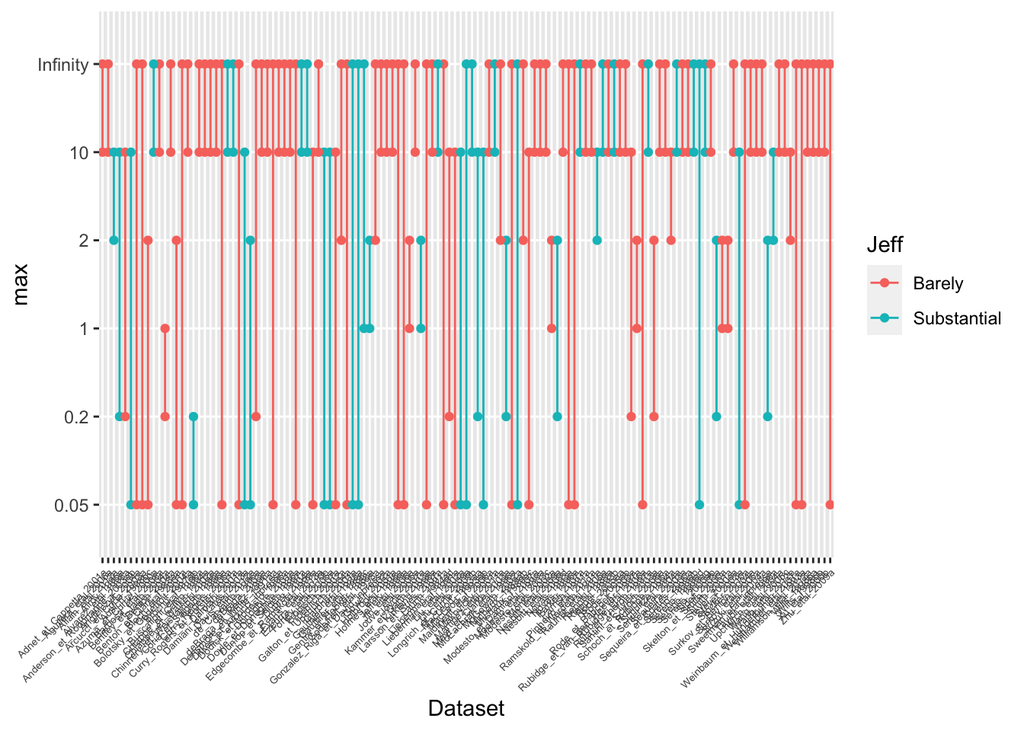

```r
small_bf <- mismatches %>%
  select(Dataset, max, Jeff)  %>%
  mutate(treatment = "BF")
small_avg <- mismatches %>%
  select(Dataset, avg_col, Jeff)  %>%
  rename(max = avg_col) %>%
  mutate(treatment = "avg")

stacked <- bind_rows(small_bf, small_avg)

stacked$max <-factor(stacked$max,levels=c(0.05, 0.2, 1,2,10, "Infinity"))

stacked %>%
  ggplot(aes(x=Dataset, y=max, color = Jeff)) +
 # ggplot(aes(x = avg_col, y = max, color = max)) +
  geom_point() +
  geom_path(aes(group = Dataset))  +
  theme(axis.text.x = element_text(angle = 45, hjust = 1, size = 5))
```